# PART II : Final Project : MATH 564

Sanketkumar Patel : A20523237

2023-12-05

```r
# Clearing workspace
rm(list = ls())

# Loading necessary libraries
library(stats)
library(corrplot)
library(car)
library(glmnet)
library(DAAG)
library(pls)
```

#Reading Data from given txt files

```r
# Reading the data from txt file
LINTHALL <- as.data.frame(read.table("/Users/sanketpatel/Documents/MATH 564/Project/LINTHALL.txt",header = TRUE))
LINTH_5 <- read.table("/Users/sanketpatel/Documents/MATH 564/Project/LINTH-5.txt",header = TRUE)

# Removing first three columns which are not necessary for the project
LINTHALL <- LINTHALL[, -c(1,2,3)]
LINTH_5 <- LINTH_5[, -c(1,2,3)]
```

**First Creating three model models to check if employed code runs correctly**

#Applying orgininal model to data

```r
# Applying ordinary least square model
Linthall_model <- lm(BIO ~ H2S + SAL + Eh7 + pH + BUF + P + K + Ca + Mg + Na + Mn + Zn + Cu + NH4, data = LINTHALL)

# Displaying summary of the model
summary(Linthall_model)
```

```
##
## Call:
## lm(formula = BIO ~ H2S + SAL + Eh7 + pH + BUF + P + K + Ca +
##     Mg + Na + Mn + Zn + Cu + NH4, data = LINTHALL)
##
## Residuals:
##    Min     1Q Median     3Q    Max
## -733.2 -131.0  -38.2  160.9  962.2
##
## Coefficients:
##               Estimate Std. Error t value Pr(>|t|)
## (Intercept)  3.476e+03  3.441e+03   1.010  0.32108
## H2S          1.154e+00  3.048e+00   0.379  0.70774
## SAL         -1.923e+01  2.658e+01  -0.723  0.47539
## Eh7          2.412e+00  1.964e+00   1.228  0.22968
## pH           1.492e+02  3.300e+02   0.452  0.65480
## BUF         -1.969e+01  1.211e+02  -0.163  0.87196
## P           -6.182e+00  3.854e+00  -1.604  0.11996
## K           -1.017e+00  4.743e-01  -2.144  0.04087 *
## Ca          -6.572e-02  1.254e-01  -0.524  0.60444
## Mg          -3.667e-01  2.730e-01  -1.343  0.18996
## Na           9.986e-03  2.430e-02   0.411  0.68421
## Mn          -3.681e+00  5.513e+00  -0.668  0.50978
## Zn          -8.082e+00  2.199e+01  -0.368  0.71599
## Cu           3.739e+02  1.104e+02   3.388  0.00211 **
## NH4         -1.551e+00  3.219e+00  -0.482  0.63366
## ---
## Signif. codes:  0 '***' 0.001 '**' 0.01 '*' 0.05 '.' 0.1 ' ' 1
##
## Residual standard error: 342.1 on 28 degrees of freedom
## Multiple R-squared:  0.8225, Adjusted R-squared:  0.7338
## F-statistic:  9.27 on 14 and 28 DF,  p-value: 4.03e-07
```

#Applying Standardized model to standardized data

```r
#Standardizing data
LINTHALL_data_standardized <- as.data.frame(lapply(LINTHALL, function(x) scale(x, center = TRUE, scale = TRUE)))

# Fitting the standardized model
LINTHALL_model_standardized <- lm(BIO ~ H2S + SAL + Eh7 + pH + BUF + P + K + Ca + Mg + Na + Mn + Zn + Cu + NH4, data = LINTHALL_data_standardized)

# Displaying summary of the model
summary(LINTHALL_model_standardized)
```

```
##
## Call:
## lm(formula = BIO ~ H2S + SAL + Eh7 + pH + BUF + P + K + Ca +
##     Mg + Na + Mn + Zn + Cu + NH4, data = LINTHALL_data_standardized)
##
## Residuals:
##      Min       1Q   Median       3Q      Max
## -1.10578 -0.19763 -0.05761  0.24264  1.45121
##
## Coefficients:
##               Estimate Std. Error t value Pr(>|t|)
## (Intercept) -9.330e-17  7.868e-02   0.000  1.00000
## H2S          5.340e-02  1.410e-01   0.379  0.70774
## SAL         -1.056e-01  1.460e-01  -0.723  0.47539
## Eh7          1.370e-01  1.116e-01   1.228  0.22968
## pH           2.846e-01  6.297e-01   0.452  0.65480
## BUF         -7.492e-02  4.606e-01  -0.163  0.87196
## P           -2.169e-01  1.352e-01  -1.604  0.11996
## K           -4.653e-01  2.170e-01  -2.144  0.04087 *
## Ca          -1.737e-01  3.315e-01  -0.524  0.60444
## Mg          -5.291e-01  3.939e-01  -1.343  0.18996
## Na           1.054e-01  2.564e-01   0.411  0.68421
## Mn          -1.380e-01  2.067e-01  -0.668  0.50978
## Zn          -1.030e-01  2.802e-01  -0.368  0.71599
## Cu           5.951e-01  1.756e-01   3.388  0.00211 **
## NH4         -1.124e-01  2.333e-01  -0.482  0.63366
## ---
## Signif. codes:  0 '***' 0.001 '**' 0.01 '*' 0.05 '.' 0.1 ' ' 1
##
## Residual standard error: 0.5159 on 28 degrees of freedom
## Multiple R-squared:  0.8225, Adjusted R-squared:  0.7338
## F-statistic:  9.27 on 14 and 28 DF,  p-value: 4.03e-07
```

#Calculating Eigen Values(i.e Lamdas’) and Eigen Vectors and generating principal components

```r
# Making Correlation matrix
correlation_matrix <- cor(LINTHALL[, c("H2S", "SAL", "Eh7", "pH", "BUF", "P", "K", "Ca", "Mg", "Na", "Mn", "Zn", "Cu", "NH4")])

# Calculating eigenvalues and eigenvectors of Correlation Matrix
result <- eigen(correlation_matrix)

# Extracting eigenvalues and eigenvectors
Lamda <- result$values
V <- result$vectors

#extracting standardized values of predictors from previous data set
extracted_values<- as.matrix(LINTHALL_data_standardized[, c("H2S", "SAL", "Eh7", "pH", "BUF", "P", "K", "Ca", "Mg", "Na", "Mn", "Zn", "Cu", "NH4")])

#Calculating principal components C1,C2...C14
PCs_Calculated=(extracted_values)%*%V
```

#Applying Principal component regression on Principal component

```r
#Merged Data frame created for  Standardized response variable & the PCs values from above calculation
data_of_Y_and_PCs <- data.frame(LINTHALL_data_standardized$BIO, PCs_Calculated)

#Changing Column Names to make code easy.
new_column_names <- c("Y_std", "c1", "c2","c3", "c4", "c5", "c6", "c7", "c8","c9", "c10", "c11", "c12","c13", "c14")
colnames(data_of_Y_and_PCs) <- new_column_names

#applying Regression model for Y_std and C1,C2,...C14
Regression_using_PCs <- lm(Y_std ~ c1+c2+c3+c4+c5+c6+c7+c8+c9+c10+c11+c12+c13+c14, data = data_of_Y_and_PCs)

#printing summary of model
summary(Regression_using_PCs)
```

```
##
## Call:
## lm(formula = Y_std ~ c1 + c2 + c3 + c4 + c5 + c6 + c7 + c8 +
##     c9 + c10 + c11 + c12 + c13 + c14, data = data_of_Y_and_PCs)
##
## Residuals:
##      Min       1Q   Median       3Q      Max
## -1.10578 -0.19763 -0.05761  0.24264  1.45121
##
## Coefficients:
##               Estimate Std. Error t value Pr(>|t|)
## (Intercept) -1.523e-16  7.868e-02   0.000  1.00000
## c1          -3.232e-01  3.501e-02  -9.231 5.46e-10 ***
## c2           1.218e-01  4.145e-02   2.938  0.00655 **
## c3          -1.616e-01  6.271e-02  -2.578  0.01551 *
## c4           1.809e-01  7.171e-02   2.523  0.01761 *
## c5           9.936e-02  9.569e-02   1.038  0.30802
## c6          -3.705e-04  1.135e-01  -0.003  0.99742
## c7           4.022e-01  1.294e-01   3.108  0.00429 **
## c8           8.059e-02  1.557e-01   0.518  0.60880
## c9          -5.335e-01  1.991e-01  -2.679  0.01221 *
## c10         -2.657e-01  2.104e-01  -1.263  0.21698
## c11         -3.950e-01  2.745e-01  -1.439  0.16130
## c12         -2.842e-01  3.737e-01  -0.761  0.45324
## c13         -3.004e-01  4.747e-01  -0.633  0.53206
## c14          2.492e-01  8.159e-01   0.305  0.76231
## ---
## Signif. codes:  0 '***' 0.001 '**' 0.01 '*' 0.05 '.' 0.1 ' ' 1
##
## Residual standard error: 0.5159 on 28 degrees of freedom
## Multiple R-squared:  0.8225, Adjusted R-squared:  0.7338
## F-statistic:  9.27 on 14 and 28 DF,  p-value: 4.03e-07
```

```r
#Extracting alpha values from the model of principal components
alpha_values<- matrix(coef(Regression_using_PCs)[-1],14,1)

# Extracting the standard errors of alpha's from the model of principal components
standard_errors <- matrix(summary(Regression_using_PCs)$coef[, 2][-1])
```

#Backtracing from PCR model to standardized model and checking if we get same value of theata or not.

```r
#Calculating Theata from the eigen vectors and alpha values obtained from above model

theta_values= V %*% alpha_values

# Create a new 14x14 matrix to store the squared elements
V_square <- matrix(0, nrow = 14, ncol = 14)

# Square each element of A and store it in B
for (i in 1:14) {
  for (j in 1:14) {
    V_square[i, j] <- V[i, j] * V[i, j]
  }
}

# Create a new 14x1 matrix to store the squared elements
Squared_standard_error <- matrix(0, nrow = 14, ncol = 1)

# Square each element of A and store it in B
for (i in 1:14) {
    Squared_standard_error[i, 1] <- standard_errors[i, 1] * standard_errors[i, 1]
}

variance_of_thata_values= V_square %*% Squared_standard_error

# Create a new 14x1 matrix to store the squared elements
Sqrt_variance_of_thata_values <- matrix(0, nrow = 14, ncol = 1)
# Square each element of A and store it in B
for (i in 1:14) {
    Sqrt_variance_of_thata_values[i, 1] <- sqrt(variance_of_thata_values[i, 1])
}

cat("Following are values of Theta:\n")
```

```
## Following are values of Theta:
```

```r
theta_values
```

```
##              [,1]
##  [1,]  0.05339976
##  [2,] -0.10559782
##  [3,]  0.13700806
##  [4,]  0.28459001
##  [5,] -0.07492329
##  [6,] -0.21685636
##  [7,] -0.46529664
##  [8,] -0.17371088
##  [9,] -0.52909104
## [10,]  0.10537812
## [11,] -0.13798542
## [12,] -0.10299747
## [13,]  0.59509124
## [14,] -0.11240567
```

```r
cat("Following are values of standard error of theta:\n")
```

```
## Following are values of standard error of theta:
```

```r
Sqrt_variance_of_thata_values
```

```
##            [,1]
##  [1,] 0.1409945
##  [2,] 0.1459592
##  [3,] 0.1115727
##  [4,] 0.6297128
##  [5,] 0.4606398
##  [6,] 0.1352053
##  [7,] 0.2170380
##  [8,] 0.3315480
##  [9,] 0.3938700
## [10,] 0.2564031
## [11,] 0.2066510
## [12,] 0.2802417
## [13,] 0.1756341
## [14,] 0.2332821
```

#employed code is right as we are getting same answer of theatas and S.E of theatas

#Backtracing from PCR model to original model and checking if we get same value of beta’s or not.

```r
# Calculate the mean of each column
means <- matrix(colMeans(LINTHALL))

# Calculate the standard deviation of each column
sds <- matrix(apply(LINTHALL, 2, sd))

#Creading one matrix for means of perdictors only
means_of_predictors <- matrix(means[2:15,1])


# Calculating beta values from book eq. 10.24
beta_values <- numeric(length = length(sds)-1)
for (i in seq_along(beta_values)) {
  beta_values[i] <- sds[1] / sds[i+1] * theta_values[i]
}

#Calculating beta_0 value from book eq. 10.24
beta_value_0<-as.numeric(means[1]-beta_values[1]*means[2]-beta_values[2]*means[3]-beta_values[3]*means[4]-beta_values[4]*means[5]-beta_values[5]*means[6]-beta_values[6]*means[7]-beta_values[7]*means[8]-beta_values[8]*means[9]-beta_values[9]*means[10]-beta_values[10]*means[11]-beta_values[11]*means[12]-beta_values[12]*means[13]-beta_values[13]*means[14]-beta_values[14]*means[15])

beta_values <- c(beta_value_0, beta_values)
beta_values <- matrix(beta_values, nrow = 15, ncol = 1)

cat("Beta Values for original model are as follows:\n")
```

```
## Beta Values for original model are as follows:
```

```r
beta_values
```

```
##                [,1]
##  [1,]  3.475951e+03
##  [2,]  1.154424e+00
##  [3,] -1.923048e+01
##  [4,]  2.411990e+00
##  [5,]  1.491615e+02
##  [6,] -1.969088e+01
##  [7,] -6.181878e+00
##  [8,] -1.016809e+00
##  [9,] -6.571561e-02
## [10,] -3.666687e-01
## [11,]  9.986448e-03
## [12,] -3.681407e+00
## [13,] -8.081782e+00
## [14,]  3.738948e+02
## [15,] -1.551010e+00
```

```r
# Create a new 14x1 matrix to store the squared elements
standard_error_of_beta <- matrix(0, nrow = 14, ncol = 1)

# Square each element of A and store it in B
for (i in 1:14) {
    standard_error_of_beta[i, 1] <- sds[1] / sds[i+1] * sqrt(variance_of_thata_values[i, 1])
}

SE_of_beta_into_means <-matrix(0, nrow = 14, ncol = 1)
# Square each element of A and store it in B
for (i in 1:14) {
    SE_of_beta_into_means[i, 1] <- standard_error_of_beta[i, 1] * means[i+1]*standard_error_of_beta[i, 1] * means[i+1]
}

# Calculate the sum of all elements in the matrix
standard_error_of_beta_0 <- sqrt(sum(SE_of_beta_into_means))

standard_error_of_beta <- as.matrix(c(standard_error_of_beta_0, standard_error_of_beta),15,1)
cat("Following are values of standard error of beta:\n")
```

```
## Following are values of standard error of beta:
```

```r
standard_error_of_beta
```

```
##               [,1]
##  [1,] 2.918784e+03
##  [2,] 3.048093e+00
##  [3,] 2.658072e+01
##  [4,] 1.964208e+00
##  [5,] 3.300499e+02
##  [6,] 1.210626e+02
##  [7,] 3.854267e+00
##  [8,] 4.742912e-01
##  [9,] 1.254261e-01
## [10,] 2.729583e-01
## [11,] 2.429875e-02
## [12,] 5.513383e+00
## [13,] 2.198940e+01
## [14,] 1.103506e+02
## [15,] 3.218901e+00
```

#Dropping Principal components based on Eigen values

```r
Lamda
```

```
##  [1] 5.172224571 3.688912029 1.611587228 1.232655581 0.692149490 0.492277471
##  [7] 0.378529840 0.261458346 0.159872076 0.143212688 0.084087717 0.045388307
## [13] 0.028124313 0.009520342
```

If we oberserve above eigen value then we can observe that lamda12, lamda13 & lamda14 are very close to zero.

As per the book : lamda_j is the variance of the jth PC, if lamda_j is approximately zero, the corresponding PC, Cj, is approximately equal to a constant. It follows that the equation defining the PC gives some idea about the type of relationship among the predictor variables that is causing collinearity.

hence we can drop C12,C13 & C14 PCs.

```r
fit <- pcr(Y_std ~., data = data_of_Y_and_PCs, validation="CV")
summary(fit)
```

```
## Data:    X dimension: 43 14
##  Y dimension: 43 1
## Fit method: svdpc
## Number of components considered: 14
##
## VALIDATION: RMSEP
## Cross-validated using 10 random segments.
##        (Intercept)  1 comps  2 comps  3 comps  4 comps  5 comps  6 comps
## CV           1.012   0.7898   0.6822   0.6493   0.6283   0.6303   0.6881
## adjCV        1.012   0.7740   0.6794   0.6480   0.6247   0.6267   0.6866
##        7 comps  8 comps  9 comps  10 comps  11 comps  12 comps  13 comps
## CV      0.5980   0.6097   0.5755    0.5748    0.5814    0.5780    0.6030
## adjCV   0.5893   0.6028   0.5701    0.5664    0.5729    0.5691    0.5924
##        14 comps
## CV       0.6507
## adjCV    0.6371
##
## TRAINING: % variance explained
##        1 comps  2 comps  3 comps  4 comps  5 comps  6 comps  7 comps  8 comps
## X        36.94    63.29    74.81    83.61    88.55    92.07    94.77    96.64
## Y_std    54.01    59.48    63.69    67.73    68.41    68.41    74.53    74.70
##        9 comps  10 comps  11 comps  12 comps  13 comps  14 comps
## X        97.78     98.81     99.41     99.73     99.93    100.00
## Y_std    79.25     80.26     81.57     81.94     82.19     82.25
```

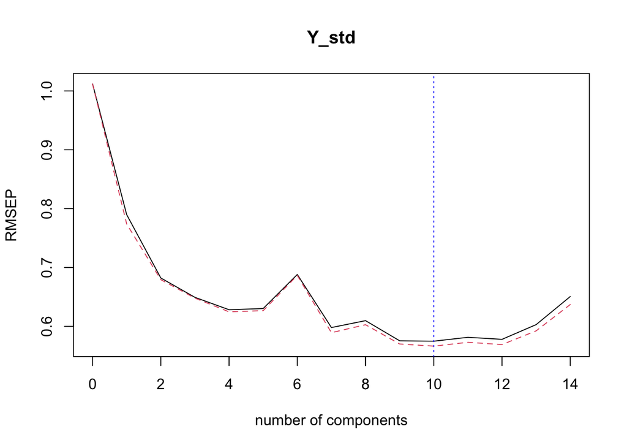

```r
validationplot(fit, val.type="RMSEP", cex.axis=1)
axis(side = 1, at = c(8), cex.axis=1)
abline(v = 10, col = "blue", lty = 3)
```

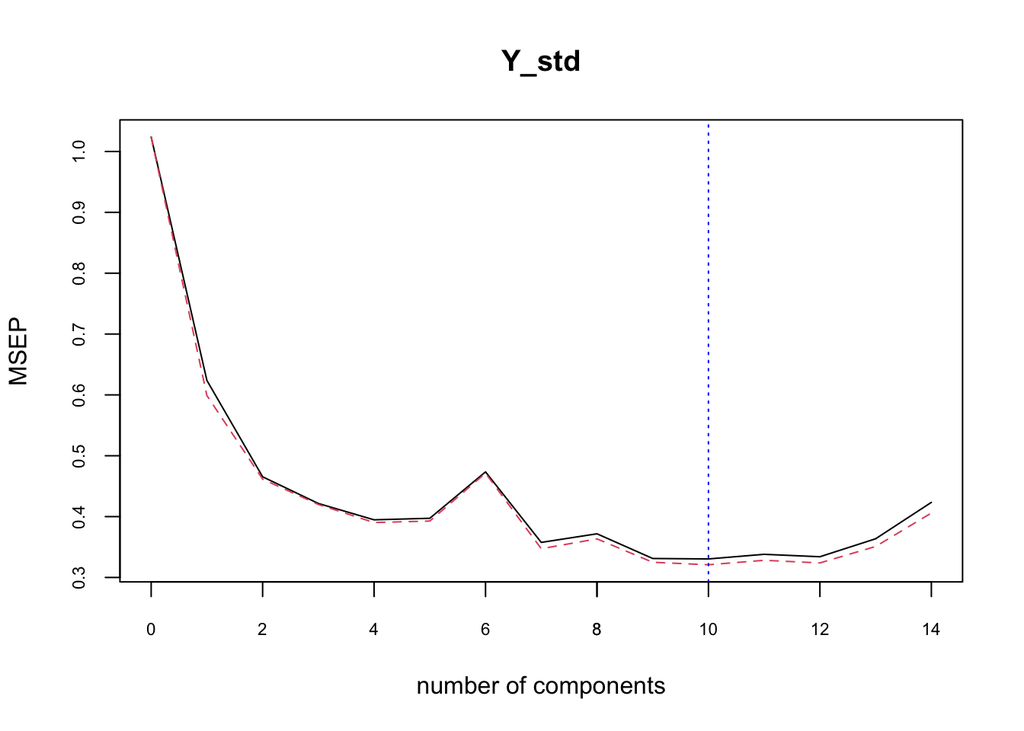

```r
validationplot(fit, val.type="MSEP", cex.axis=0.7)
axis(side = 1, at = c(8), cex.axis=0.7)
abline(v = 10, col = "blue", lty = 3)
```

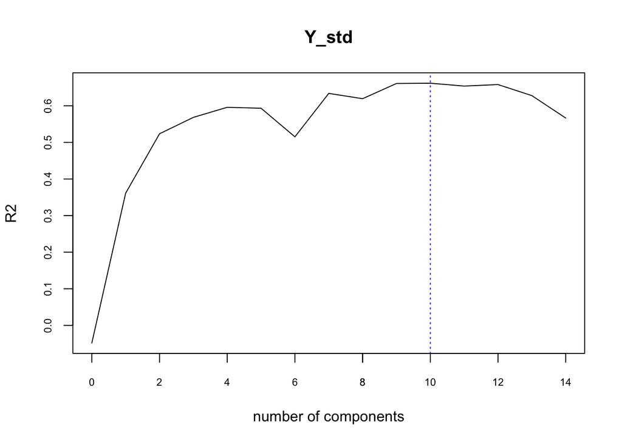

```r
validationplot(fit, val.type="R2", cex.axis=0.7)
axis(side = 1, at = c(8), cex.axis=0.7)
abline(v = 10, col = "blue", lty = 3)
```

**Applying Principal components for remaining 11 Principal components.**

```r
#applying Regression model for Y_std and C1,C2 and C3 (Reduced Model)
Regression_using_Reduced_PCs <- lm(Y_std ~ c1+c2+c3+c4+c5+c6+c7+c8+c9+c10+c11, data = data_of_Y_and_PCs)

#printing summary of reduced model
summary(Regression_using_Reduced_PCs)
```

```
##
## Call:
## lm(formula = Y_std ~ c1 + c2 + c3 + c4 + c5 + c6 + c7 + c8 +
##     c9 + c10 + c11, data = data_of_Y_and_PCs)
##
## Residuals:
##      Min       1Q   Median       3Q      Max
## -1.09654 -0.23053 -0.01144  0.14459  1.44232
##
## Coefficients:
##               Estimate Std. Error t value Pr(>|t|)
## (Intercept)  8.525e-17  7.620e-02   0.000  1.00000
## c1          -3.232e-01  3.390e-02  -9.533 9.93e-11 ***
## c2           1.218e-01  4.014e-02   3.033  0.00486 **
## c3          -1.616e-01  6.073e-02  -2.662  0.01221 *
## c4           1.809e-01  6.944e-02   2.605  0.01399 *
## c5           9.936e-02  9.267e-02   1.072  0.29193
## c6          -3.705e-04  1.099e-01  -0.003  0.99733
## c7           4.022e-01  1.253e-01   3.209  0.00309 **
## c8           8.059e-02  1.508e-01   0.534  0.59682
## c9          -5.335e-01  1.928e-01  -2.767  0.00946 **
## c10         -2.657e-01  2.037e-01  -1.304  0.20174
## c11         -3.950e-01  2.659e-01  -1.486  0.14746
## ---
## Signif. codes:  0 '***' 0.001 '**' 0.01 '*' 0.05 '.' 0.1 ' ' 1
##
## Residual standard error: 0.4996 on 31 degrees of freedom
## Multiple R-squared:  0.8157, Adjusted R-squared:  0.7504
## F-statistic: 12.48 on 11 and 31 DF,  p-value: 1.568e-08
```

**Calculating Theata from the eigen vectors and alpha values obtained from above reduced model**

```r
# Extracting the coefficients
coefficients <- Regression_using_Reduced_PCs$coefficients

#Making alpha values matrix from the extracted coefficient
alpha_values_for_reduced_model <- c(coefficients["c1"], coefficients["c2"], coefficients["c3"],coefficients["c4"], coefficients["c5"], coefficients["c6"],coefficients["c7"], coefficients["c8"], coefficients["c9"],coefficients["c10"], coefficients["c11"], 0, 0,0)

#Changing it to matrix to perform matrix multiplication
alpha_values_for_reduced_model<-matrix(alpha_values_for_reduced_model,14,1)

#Calculating theata values
theta_values_for_reduced_model=V%*%alpha_values_for_reduced_model


# Extract the standard errors
standard_errors_reducemodel <- rbind(matrix(summary(Regression_using_Reduced_PCs)$coef[, 2][-1]),matrix(0, nrow = 3, ncol = 1))


# Create a new 14x1 matrix to store the squared elements
Squared_std_errors_reducemodel <- matrix(0, nrow = 14, ncol = 1)

# Square each element of A and store it in B
for (i in 1:14) {
    Squared_std_errors_reducemodel[i, 1] <- standard_errors_reducemodel[i, 1] * standard_errors_reducemodel[i, 1]
}

variance_of_thata_values_reducedmodel= V_square %*% Squared_std_errors_reducemodel

# Create a new 14x1 matrix to store the squared elements
Sqrt_variance_of_thata_values_reducedmodel <- matrix(0, nrow = 14, ncol = 1)
# Square each element of A and store it in B
for (i in 1:14) {
    Sqrt_variance_of_thata_values_reducedmodel[i, 1] <- sqrt(variance_of_thata_values_reducedmodel[i, 1])
}

cat("Following are values of Theta values for reduced model:\n")
```

```
## Following are values of Theta values for reduced model:
```

```r
theta_values_for_reduced_model
```

```
##              [,1]
##  [1,]  0.07226232
##  [2,] -0.10776196
##  [3,]  0.12040565
##  [4,]  0.19609960
##  [5,] -0.25698537
##  [6,] -0.20982436
##  [7,] -0.54088342
##  [8,] -0.18981155
##  [9,] -0.17729676
## [10,] -0.11389563
## [11,] -0.14465882
## [12,] -0.16317405
## [13,]  0.51389265
## [14,] -0.05438080
```

```r
cat("Following are values of standard error of theta for reduced model:\n")
```

```
## Following are values of standard error of theta for reduced model:
```

```r
Sqrt_variance_of_thata_values_reducedmodel
```

```
##             [,1]
##  [1,] 0.11986140
##  [2,] 0.10439035
##  [3,] 0.10429616
##  [4,] 0.04900197
##  [5,] 0.10650161
##  [6,] 0.12359162
##  [7,] 0.16773551
##  [8,] 0.15045644
##  [9,] 0.06222226
## [10,] 0.12831815
## [11,] 0.13538166
## [12,] 0.17590090
## [13,] 0.12450238
## [14,] 0.13674621
```

**Answer of sub question of part II:compute the regression coefficients βˆj in the original multiple linear regression model.**

```r
# Calculate beta values
beta_values_for_reduced_model <- numeric(length = length(sds)-1)
for (i in seq_along(beta_values_for_reduced_model)) {
  beta_values_for_reduced_model[i] <- sds[1] / sds[i+1] * theta_values_for_reduced_model[i]
}

beta_values_for_reduced_model_0<-as.numeric(means[1]-beta_values_for_reduced_model[1]*means[2]-beta_values_for_reduced_model[2]*means[3]-beta_values_for_reduced_model[3]*means[4]-beta_values_for_reduced_model[4]*means[5]-beta_values_for_reduced_model[5]*means[6]-beta_values_for_reduced_model[6]*means[7]-beta_values_for_reduced_model[7]*means[8]-beta_values_for_reduced_model[8]*means[9]-beta_values_for_reduced_model[9]*means[10]-beta_values_for_reduced_model[10]*means[11]-beta_values_for_reduced_model[11]*means[12]-beta_values_for_reduced_model[12]*means[13]-beta_values_for_reduced_model[13]*means[14]-beta_values_for_reduced_model[14]*means[15])

beta_values_for_reduced_model <- matrix(c(beta_values_for_reduced_model_0, beta_values_for_reduced_model))

cat("Beta Values for reduced model are as follows:\n")
```

```
## Beta Values for reduced model are as follows:
```

```r
beta_values_for_reduced_model
```

```
##                [,1]
##  [1,] 3998.59701701
##  [2,]    1.56220499
##  [3,]  -19.62459460
##  [4,]    2.11970908
##  [5,]  102.78122696
##  [6,]  -67.53933514
##  [7,]   -5.98141847
##  [8,]   -1.18198791
##  [9,]   -0.07180656
## [10,]   -0.12286954
## [11,]   -0.01079363
## [12,]   -3.85945088
## [13,]  -12.80358779
## [14,]  322.87786798
## [15,]   -0.75036386
```

**Answer of sub question of part II:Compare the standard error sum Pj s.e.(βˆj ) and SSE with their counterparts in Part I.**

```r
# Create a new 14x1 matrix to store the squared elements
standard_error_of_beta_reduced <- matrix(0, nrow = 14, ncol = 1)

# Square each element of A and store it in B
for (i in 1:14) {
    standard_error_of_beta_reduced[i, 1] <- sds[1] / sds[i+1] * sqrt(variance_of_thata_values_reducedmodel[i, 1])
}


SE_of_beta_reducedmodel_into_means <-matrix(0, nrow = 14, ncol = 1)
# Square each element of A and store it in B
for (i in 1:14) {
    SE_of_beta_reducedmodel_into_means[i, 1] <- standard_error_of_beta_reduced[i, 1] * means[i+1]
}

# Calculate the sum of all elements in the matrix
matrix_sum <- sum(SE_of_beta_reducedmodel_into_means)


SE_of_beta_for_reduced_model <- matrix(c(matrix_sum, standard_error_of_beta_reduced))

cat("\nStandard error beta for reduced model are as follows:\n")
```

```
##
## Standard error beta for reduced model are as follows:
```

```r
SE_of_beta_for_reduced_model
```

```
##               [,1]
##  [1,] 396.44581102
##  [2,]   2.59122716
##  [3,]  19.01058752
##  [4,]   1.83610583
##  [5,]  25.68328752
##  [6,]  27.99010571
##  [7,]   3.52320016
##  [8,]   0.36655098
##  [9,]   0.05691835
## [10,]   0.04312104
## [11,]   0.01216042
## [12,]   3.61193920
## [13,]  13.80221046
## [14,]  78.22462859
## [15,]   1.88686855
```

```r
standard_errors_full_model <- matrix(summary(Linthall_model)$coef[, 2])
cat("\nStandard error beta for full model are as follows:\n")
```

```
##
## Standard error beta for full model are as follows:
```

```r
standard_errors_full_model
```

```
##               [,1]
##  [1,] 3.441050e+03
##  [2,] 3.048093e+00
##  [3,] 2.658072e+01
##  [4,] 1.964208e+00
##  [5,] 3.300499e+02
##  [6,] 1.210626e+02
##  [7,] 3.854267e+00
##  [8,] 4.742912e-01
##  [9,] 1.254261e-01
## [10,] 2.729583e-01
## [11,] 2.429875e-02
## [12,] 5.513383e+00
## [13,] 2.198940e+01
## [14,] 1.103506e+02
## [15,] 3.218901e+00
```

```r
cat("\nSum Standard error beta for reduced model is:", sum(SE_of_beta_for_reduced_model))
```

```
##
## Sum Standard error beta for reduced model is: 575.0847
```

```r
cat("\nSum Standard error beta for full model is:", sum(standard_errors_full_model))
```

```
##
## Sum Standard error beta for full model is: 4069.579
```

**Above is the comparison of Sum of standard error beta.**

#Note: Not able to calculate S.E of beta_0 properly from the formula.

**Comparing SSE of full model and reduced model**

```r
sse1 <- sum(residuals(Linthall_model)^2)

cat("\nSSE for full model are as follows:",sse1)
```

```
##
## SSE for full model are as follows: 3276740
```

```r
Dumy_linthall<- LINTHALL
Dumy_linthall <- as.matrix(Dumy_linthall)

beta_values_for_reduced_model <- as.matrix(as.numeric(beta_values_for_reduced_model))

# Assuming Dumy_linthall is your data frame
Dumy_linthall[, 1] <- 1

Y_predict <- Dumy_linthall %*% beta_values_for_reduced_model

Residuals_calculated<- LINTHALL[,1] - Y_predict[,1]

SSe<-sum(Residuals_calculated^2)

cat("\nSSE for reduced model are as follows:", SSe)
```

```
##
## SSE for reduced model are as follows: 3402208
```

**SSE has increase for the reduced model**